# Practical Machine Learning Course Project

Alex Sickert

14 July 2016

In this assignment I analyze data from accelerometers on the belt, forearm, arm, and dumbell of 6 participants.The goal of the project is to predict the manner in which the participants did the exercise.

In order to do this assignment I use the libraries “caret” and “randomForest”.

## Introduction

Training and test data are provided via a link to a website where CSV files are stored. The test data is then used to predict the class a certain observation belongs to. Overall for 20 cases. Subsequently this result is used on the Coursera website in a quizz.

## Load Data

We load the data by downloading it from the website and parse it as CSV. We directly declare “NA” Strings as NA vlaues.

```r
train_data <- read.csv("https://d396qusza40orc.cloudfront.net/predmachlearn/pml-training.csv", header=TRUE, sep=",", na.strings=c("NA",""))


#summary(train_data)
#head(train_data)
```

## Clean Data

After a some exploratory analysis of the dataset I realized that many columns do not contain valuable information. Many columns contain NA data. We remove these columns to have a feature set that is more meaningful.

```r
#colnames(train_data)

train_data_feature_set_columns <- colnames(train_data[colSums(is.na(train_data)) == 0])[-(1:7)]

model_data <- train_data[train_data_feature_set_columns]
```

## Chosing approach

There are various approaches how to create prediction models for performing classification. For this project I use random forest. Because it tends to be very accurate. I also tried out simpler trees. However, the execution time for the code was unacceptably long. And only the code using the randomForest package had short execution time. Therefore I continued using randomforest.

## Create partitions

First I split the data in a training and test data set.

```r
partition <- createDataPartition(y=model_data$classe, p=0.7, list=FALSE )
training <- model_data[partition,]
testing <- model_data[-partition,]
```

Then I create the prediction model using the training data set. This step takes a lot of time for calulation. On my computer more than 1 hour.

```r
modFit <- randomForest(classe ~ .,   data=training)
```

I wanted to understand how the tree approximately looks like and how accurate it preditcts. Therefore I obtained certain data on it:

```r
modFit
```

```
##
## Call:
##  randomForest(formula = classe ~ ., data = training)
##                Type of random forest: classification
##                      Number of trees: 500
## No. of variables tried at each split: 7
##
##         OOB estimate of  error rate: 0.53%
## Confusion matrix:
##      A    B    C    D    E  class.error
## A 3904    2    0    0    0 0.0005120328
## B   17 2638    3    0    0 0.0075244545
## C    0   13 2380    3    0 0.0066777963
## D    0    0   26 2225    1 0.0119893428
## E    0    0    2    6 2517 0.0031683168
```

Then I want to know which variable is most important to predict the class. I plot them in a graph.

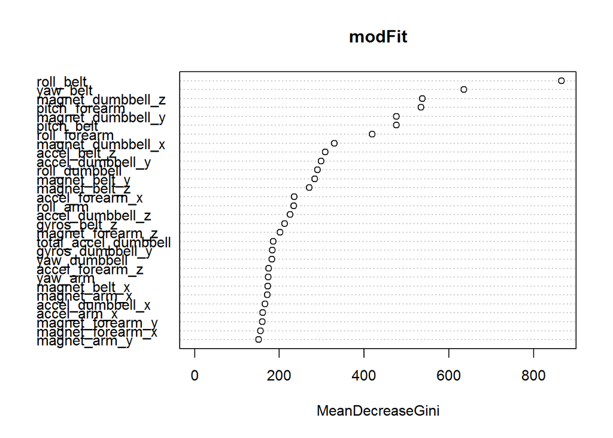

```r
#importance(modFit) # importance of each predictor
varImpPlot(modFit)
```

## Create predictions and evaluate outcome

Now we apply the model to the train and test data and create a confustion matrix which allows us understanding who well the model predicts the classificaton.

First we apply the model to the training dataset. Here it should work verz accuratly. But it could be subject to overfitting.

```r
predictions1 <- predict(modFit, newdata=training)
confusionMatrix(predictions1,training$classe)
```

```
## Confusion Matrix and Statistics
##
##           Reference
## Prediction    A    B    C    D    E
##          A 3906    0    0    0    0
##          B    0 2658    0    0    0
##          C    0    0 2396    0    0
##          D    0    0    0 2252    0
##          E    0    0    0    0 2525
##
## Overall Statistics
##
##                Accuracy : 1
##                  95% CI : (0.9997, 1)
##     No Information Rate : 0.2843
##     P-Value [Acc > NIR] : < 2.2e-16
##
##                   Kappa : 1
##  Mcnemar's Test P-Value : NA
##
## Statistics by Class:
##
##                      Class: A Class: B Class: C Class: D Class: E
## Sensitivity            1.0000   1.0000   1.0000   1.0000   1.0000
## Specificity            1.0000   1.0000   1.0000   1.0000   1.0000
## Pos Pred Value         1.0000   1.0000   1.0000   1.0000   1.0000
## Neg Pred Value         1.0000   1.0000   1.0000   1.0000   1.0000
## Prevalence             0.2843   0.1935   0.1744   0.1639   0.1838
## Detection Rate         0.2843   0.1935   0.1744   0.1639   0.1838
## Detection Prevalence   0.2843   0.1935   0.1744   0.1639   0.1838
## Balanced Accuracy      1.0000   1.0000   1.0000   1.0000   1.0000
```

As a next step we apply it to the testing set. The prediction should be a bit worse as the prediction with the training set is often subject to overfitting.

```r
predictions2 <- predict(modFit, newdata=testing)
confusionMatrix(predictions2,testing$classe)
```

```
## Confusion Matrix and Statistics
##
##           Reference
## Prediction    A    B    C    D    E
##          A 1672    7    0    0    0
##          B    0 1130   11    0    0
##          C    2    2 1013   14    0
##          D    0    0    2  948    1
##          E    0    0    0    2 1081
##
## Overall Statistics
##
##                Accuracy : 0.993
##                  95% CI : (0.9906, 0.995)
##     No Information Rate : 0.2845
##     P-Value [Acc > NIR] : < 2.2e-16
##
##                   Kappa : 0.9912
##  Mcnemar's Test P-Value : NA
##
## Statistics by Class:
##
##                      Class: A Class: B Class: C Class: D Class: E
## Sensitivity            0.9988   0.9921   0.9873   0.9834   0.9991
## Specificity            0.9983   0.9977   0.9963   0.9994   0.9996
## Pos Pred Value         0.9958   0.9904   0.9825   0.9968   0.9982
## Neg Pred Value         0.9995   0.9981   0.9973   0.9968   0.9998
## Prevalence             0.2845   0.1935   0.1743   0.1638   0.1839
## Detection Rate         0.2841   0.1920   0.1721   0.1611   0.1837
## Detection Prevalence   0.2853   0.1939   0.1752   0.1616   0.1840
## Balanced Accuracy      0.9986   0.9949   0.9918   0.9914   0.9993
```

```r
table(predictions2, testing$classe)
```

```
##
## predictions2    A    B    C    D    E
##            A 1672    7    0    0    0
##            B    0 1130   11    0    0
##            C    2    2 1013   14    0
##            D    0    0    2  948    1
##            E    0    0    0    2 1081
```

## Apply the model to the test data and process it with provided code

Finally I use the model for predicting the classes of the dataset that was provided.

```r
quizz_data <- read.csv("https://d396qusza40orc.cloudfront.net/predmachlearn/pml-testing.csv", header=TRUE, sep=",", na.strings=c("NA",""))

#head(quizz_data)

#train_data_feature_set_columns

result <- predict(modFit, newdata=quizz_data)

result
```

```
##  1  2  3  4  5  6  7  8  9 10 11 12 13 14 15 16 17 18 19 20
##  B  A  B  A  A  E  D  B  A  A  B  C  B  A  E  E  A  B  B  B
## Levels: A B C D E
```

## Conclusion

After submitting the result to the quizz it turns out at the result is correct.